# The Landscape of AI Evaluation

Week 1

2026-09-01

## Me

- PhD in Political Methodology from NYU
  - Experimentation, Causal Inference, Machine Learning
- Facebook Core Data Science (now “Meta Central Applied Science”)
  - Adaptive Experimentation team
  - Bayesian Optimization
  - Routine Experimentation
- Academia
  - Professor of Data Science for the Common Good

Research:

- Better integration of machine learning and experiments
- Causal Machine Learning
- Helping people study the internet using these tools

[figure not shown]

# Housekeeping

## Today

- How will this course actually work?
  - Structure, assignments, teams, grading
- What does it mean to evaluate an AI system?
  - And why is it harder than it looks?
- What do *you* need to do before next week?

## What this course is

- You will design, pre-register, run, and write up one real evaluation of an AI system
  - In teams of ~4, over the whole term
- The premise: AI systems are tools humans use to accomplish tasks
  - So evaluating them is a question about human-AI performance on real tasks
  - Not (only) about abstract model capability
- The methodology comes from social science: measurement theory and experimental design

## What this course is *not*

- Not a course about building or training models
- Not a survey where you write a final essay about evaluation
  - You will produce an actual evaluation, with data, code, and results
- Not a course where things go according to plan
  - Real studies break; dealing with that is part of the syllabus

## The arc of the term

```
flowchart LR
    A["Weeks 1–2<br/>Pitch & form teams"] --> B["Weeks 3–7<br/>Design the evaluation"]
    B --> C["Week 8<br/>Register the PAP"]
    C --> D["Weeks 9–11<br/>Run it"]
    D --> E["Week 12 +<br/>Present & report"]
```

- First two-thirds: design and pre-register an evaluation
- Last third: run it, handle the surprises, write it up
- Once the pre-analysis plan is registered (week 8), deviations must be documented and justified

## How each session works

- Most sessions have two parts:
  - Workshop first: teams iterate on this week’s milestone, with the class and me, supported by that week’s readings
  - Short lecture after: previews *next* week’s milestone
- So you meet every topic three times:
1. Lecture (a week ahead)
2. Reading (before the session that workshops it)
3. Workshop (applied to your own project)
- Today and next week are the exceptions: no groups, no projects!

## Schedule for this class

1. The landscape of AI evaluation
2. Problem pitches & team formation
3. Construct and problem setup
4. Instrument design
5. Outcome measurement & scorers
6. Experimental design & validity
7. Analysis plan
8. PAP workshop & sign-off
9. Implementation I: pilots
10. Implementation II: troubleshooting
11. Analysis and draft findings
12. Final presentations

FINAL REPORT (end of exam period)

## Two design archetypes

Both ask: how does AI change human capabilities?

Human-subjects experiment

- The unit is a *person*: real people do a real task, randomized connection to AI
- You observe the human–AI system directly
- Ethics review, recruitment, participant budget

Model-only evaluation

- The unit is a *task instance*: the system is scored against what a person would otherwise do
- You observe the system, and argue from there to the person
- Data provenance, scoring, API credits
- Every team commits to one of these (week 3), with an argument for the choice
- The choice is about *what you can measure and defend*

## Teams and stewards

- Teams of ~4, formed in week 2 around topics the class votes on
- Each team assigns four stewards — one per graded deliverable:
  - Ethics steward → ethics self-assessment (A2) — *by 6 Oct*
  - PAP steward → pre-analysis plan (A3) — *by Fri 30 Oct*
  - Implementation steward → WIP presentations & pipeline (A4) — *3 & 10 Nov*
  - Report steward → final report (A5) — *end of exam period*
- Stewardship = *organizing* that deliverable: issues, review, coordination
  - Not doing all the work yourself — and each deliverable has a different steward

## Working in the open on GitHub

- All project work happens in a shared repo in the course GitHub organization
  - Changes land through pull requests, not direct commits
  - Tasks and decisions tracked as issues
  - Work organized on a project board
- 5 points of each team deliverable are for *process*, assessed from the GitHub history
- The goal: your real collaboration is legible
  - Distributed contribution across the term, not a last-minute burst

## Grading

| Assignment | Deadline | Weight |
| --- | --- | --- |
| A1: Reading reflection memos (×2 per student) | Rolling, 24h before session | 20% |
| A2: Ethics & responsible-evaluation self-assessment | By 6 Oct | 10% |
| A3: Pre-analysis plan (registered) | Fri 30 Oct | 20% |
| A4: Implementation WIP presentations | 3 & 10 Nov | 10% |
| A5: Final team report + individual reflection | End of exam period | 30% |
| Participation | — | 10% |

- Late work: −10% per day
- You may miss up to 2 of 12 sessions

## A1: Reading reflection memos

- Each student writes two memos over the term, each on one week’s required reading
- At most one page, on GitHub, 24 hours before the session
- The prompt is project-oriented:
  - *What does this reading tell you about your team’s evaluation?*
  - *What would you change about your design as a result?*
- Coordinate within your team so memos don’t overlap
- Graded by completion

## A2 & A3: Ethics, then the pre-analysis plan

- A2 (by 6 October 2026): responsible-evaluation self-assessment
  - Human-subjects teams: Hertie self-assessment checklist (consent, vulnerable participants, deception & covert research, sensitive content, GDPR)
    - Feeds the ethics review arranged through Hertie – so start it in week 4
  - Model-only teams: data & responsibility statement (provenance, licensing, rater labor, dual-use & disclosure)
    - Plus scope conditions: what your design does and does *not* license you to claim
- A3 (draft for session 8, registered by Friday 30 October): the pre-analysis plan
  - The whole study written down *before* you run it: what varies, on whom or what, what you measure, and how you will analyze it
  - Question, construct, instrument, outcomes & scoring, randomization, sample & power, hypotheses, estimation, threats to validity
  - Registered on OSF: after that, deviations are documented, not hidden

## A4 & A5: Running it and writing it up

- A4 (sessions 9–10): two work-in-progress presentations
  - Deliberately informal: code demo + status report
  - Graded on how usefully they expose your real state
    - Too much polish could be a negative signal!
- A5 (end of exam period): final team report
  - 10–15 pages, literate & reproducible (Quarto/notebook), with code and data
  - Includes the registered PAP, a “deviations and surprises” section, and honest limitations
  - Plus an individual one-page reflection from each student

## Resources you get

- Participant recruitment budget (professor-administered) for human-subjects teams
  - A common pool of 1-2000€
  - Roughly 500 participants through Prolific
- API credits for every student, with more available if justified in your PAP
  - Each student gets 100€ attached to a single API key from OpenRouter
- Ethics review arranged through Hertie
- Readings, templates, and rubrics on the course GitHub

## Policy on AI tools

- AI tools are permitted throughout the course (except closed-book assessments)
  - Include a Statement of Authorship in written work
  - Undisclosed use is an academic-integrity violation
- More than permitted: *expected*
  - The subject of this course is evaluating AI systems
  - Use them, and bring critical attention to how they shape your own work

## Office hours

- Wednesdays from 9:30 to 11:30, unless otherwise announced
- Or by appointment: email me
- Come as a team if the question is a team question, or send the steward

Good examples of things to come with:

- “How can we turn our topical interest into a concrete evaluation question?”
- A design decision you’re stuck on
- Scope: can four people actually run this in a semester?
- Ethics, recruitment, or API problems — *early*, while they’re still fixable
- Anything breaking in the implementation phase
- No appointment needed to just come talk about evaluation, research, theses, or books

# The landscape of AI evaluation

## Everyone is evaluating AI, all the time

[figure not shown]

The leaderboard: “these are the best models” (LMArena)

[figure not shown]

The headline: “AI passes the exam” (CNN, 2023)

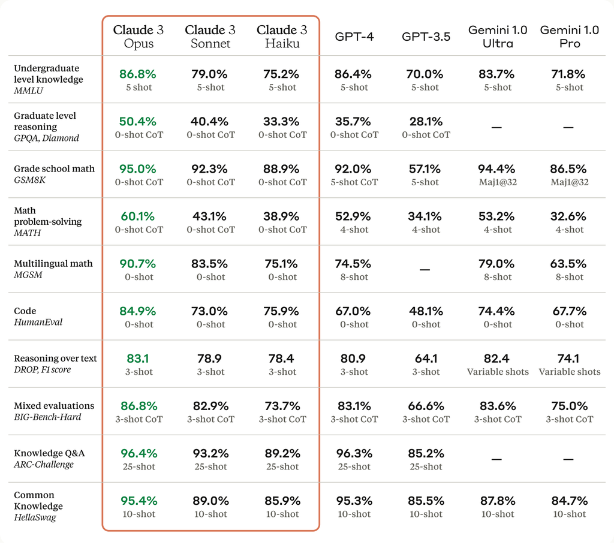

The release post: “state of the art on GPQA” (Anthropic, 2024)

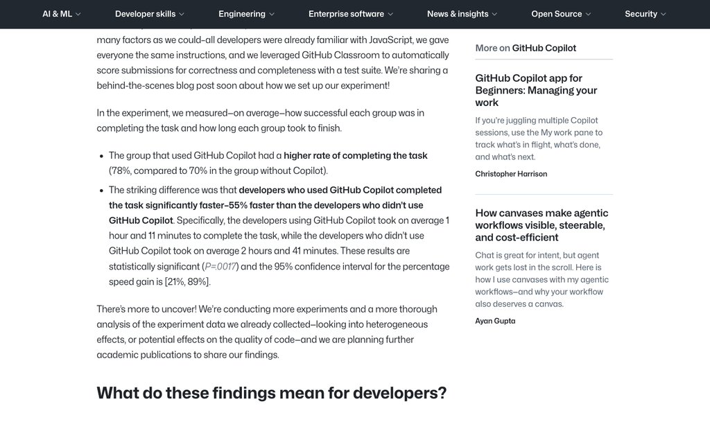

The vendor pitch: “55% faster with our tool” (GitHub, 2022)

- Each is a measurement claim.
- This course aims at answering the question: how do we know?

## Two kinds of question

The capability question

> Can the model do *X*?
- GPT-4 scores in the top decile of bar exam takers
- True, replicable, well-defined
- A claim about the model, on a fixed task

The deployment question

> Does it help a *person* do *Y*?
- Should a legal-aid clinic let paralegals draft filings with it?
- Unanswered by the bar exam score
- A claim about a human-AI system, in real work
- For tools meant to help people work, deployment is the question that counts
  - Capability is evidence *toward* it — not a substitute for it
- Some capability questions are decision-relevant on their own
  - e.g. *can a system enable a dangerous act, or resist one?*

## The claim of this course

- Two cheap postures, both useless:
  - Credulity — *90th percentile; we’ve solved law!*
  - Cynicism — *benchmarks are just marketing: nobody knows anything*
- The third posture: an evaluation is a research design: a chain that runs from a purpose to a claim
  - Each link breaks in its own nameable way
  - So you can *diagnose* how a number went wrong
  - This critical frame will allow you to design better evaluations

*“This benchmark is flawed”* is `¯\_(ツ)_/¯`.

*“This benchmark has a coverage problem, and here is the sample that would fix it”*.

[Martínez (2024)](https://doi.org/10.1007/s10506-024-09396-9) *Re-evaluating GPT-4’s Bar Exam Performance*

## A benchmark worth taking seriously

SWE-bench: a standard for “can it write real code?”

The task

- 2,294 real issues from 12 popular Python repositories (Django, sympy, scikit-learn, …)
  - the widely-reported variant, *Verified*, is a 500-issue human-checked subset
- In: the issue text plus a snapshot of the repository at that commit
- Out: a patch

The verdict

- Scored programmatically: hidden tests that must go fail → pass, plus tests that must stay passing
- Reported as one number per model: *“resolves n% of issues”*

Real tasks, real repositories, an objective scorer.

- Programmatic scoring: the grader is code — a unit test here, an exact match or a reference answer elsewhere
- It is reliable (same output, same score, twice), cheap to rerun, and auditable — the criterion sits in a repository, not in a rater’s head

## So what could still go wrong?

- Is *“closes an issue”* software engineering?
- Twelve Python repositories — who writes this kind of code, and who doesn’t?
- The harness retrieves, runs the tests, and retries — the score credits the model
- The accepted patch, or *a* patch that passes the tests?
- The fix is already in public GitHub history
- One number — for a model, or for a whole scaffold?
- None of these is a reason to throw the benchmark out
  - Each is a different kind of failure, at a different point in the design
  - These failures are the kind of thing social science has been focused on for decades

## What the number leaves out

The score is a property of a whole system: the leaderboard attributes to a model

Fixed by the benchmark

- The task sample: which repos, which issues
- The scorer: those hidden tests
- The success criterion: patch makes tests pass

Chosen by whoever ran it

- Retrieval: which files it ever sees
- Tools: can it run tests and iterate?
- Attempts: one patch, or best of many
- Prompt and harness: SWE-agent, Agentless, a vendor’s own agent
- Swap just the harness and measured performance changes
  - 40× in compute — and 0–8 points in success rate, within noise
- In real deployments the system extends past both columns
  - Inward, to the person using it: a tool that helps an expert and misleads a novice has no single performance level
  - Outward, to the society it runs in: who bears the errors, and who needed this done

[Vats & Golev (2026)](https://arxiv.org/abs/2607.22585) *The Scaffold Effect in Coding Agents*

[Augment Code (2026)](https://www.augmentcode.com/blog/auggie-tops-swe-bench-pro) *Auggie tops SWE-bench Pro*

## Realism of environment vs. realism of purpose

Two things get called “realistic” — and they come apart

Realism of *environment*

The task looks like real work: real code, real tools, real difficulty

- *Rewriting SQLite from nothing but its documentation*
- Buys difficulty: hard enough to pull systems apart
- Risks irrelevance: a score with nobody downstream of it

Realism of *purpose*

The task is something a real person needs: real stakes, real user

- *A dentist’s office wanting its own appointment system*
- Buys a standard: someone who can say if it worked
- Risks saturation: real need, but every system passes
- Neither is sufficient
  - purpose without difficulty gives you no differentiation
  - difficulty without purpose gives you no meaning
- $\implies$ *for what claim* is this realistic?

[Cursor (2026)](https://cursor.com/blog/agent-swarm-model-economics) *Agent swarms and the new model economics*

## The same chain, every time

- Those doubts were not ad hoc: each one sits at a link every evaluation has

```
%%{init: {"theme": "base", "flowchart": {"nodeSpacing": 60, "rankSpacing": 26, "padding": 6}, "themeVariables": {
  "primaryColor": "#ffffff", "primaryBorderColor": "#3b5998", "primaryTextColor": "#2d3748",
  "lineColor": "#6c757d", "edgeLabelBackground": "#ffffff",
  "fontFamily": "Domitian, Palatino, serif", "fontSize": "22px"}}}%%
flowchart TD
    A["PURPOSE"] --> B["INQUIRY"]
    B --> S["SAMPLE"]
    S --> C["EVALUATION DESIGN"]
    C --> D["OBSERVED EVIDENCE"]
    D --> E["ANSWER / CLAIM"]
    e1["<b style='color:#ba0020'>construct error</b> <i style='font-size:17px;color:#8a94a0'>(week 3)</i><br/>the question is not the thing that matters"] -.-> B
    e2["<b style='color:#ba0020'>coverage &amp; sampling error</b> <i style='font-size:17px;color:#8a94a0'>(week 6)</i><br/>these users, tasks, and prompts stand in badly for the ones you care about"] -.-> S
    e3["<b style='color:#ba0020'>implementation &amp; assignment error</b> <i style='font-size:17px;color:#8a94a0'>(weeks 4 & 9–10)</i><br/>the study does not create the comparison it says it does"] -.-> C
    e4["<b style='color:#ba0020'>measurement, scoring &amp; contamination error</b> <i style='font-size:17px;color:#8a94a0'>(week 5)</i><br/>the score is a noisy or invalid stand-in for performance"] -.-> D
    e5["<b style='color:#ba0020'>analysis &amp; inference error</b> <i style='font-size:17px;color:#8a94a0'>(weeks 7 & 11)</i><br/>the answer overstates the evidence, or travels farther than the design permits"] -.-> E
    e0[" "] ~~~ e1
    e1 ~~~ e2
    e2 ~~~ e3
    e3 ~~~ e4
    e4 ~~~ e5
    classDef err fill:#ffffff,stroke:#ba0020,stroke-width:1px,stroke-dasharray:5 4,color:#6c757d;
    classDef spacer fill:none,stroke:none;
    class e1,e2,e3,e4,e5 err
    class e0 spacer
    style E stroke:#ba0020,stroke-width:2px
    linkStyle 5,6,7,8,9 stroke:#ba0020,stroke-width:1.5px
```

## Benchmarks: the workhorse

- A benchmark is three things bolted together
  - a fixed task set, an automatic scorer, and one number

MMLU fills in that template:

- Task set: ~15,900 questions across 57 subjects, collected from real exams
- Scorer: every question has four options and one marked answer, so grading is a letter comparison — the same programmatic idea, at its cheapest
- Number: the share of questions answered correctly
- The subjects are the claim: breadth is what makes the score feel like a measure of the model rather than of one task

## What an MMLU item looks like

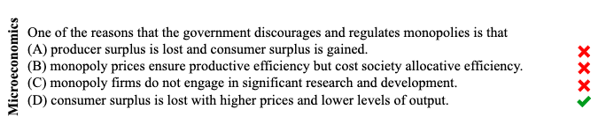

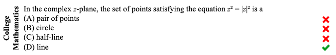

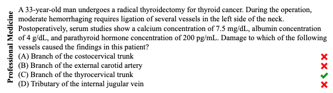

Hendrycks, D. et al. (2021). [Measuring Massive Multitask Language Understanding](https://arxiv.org/abs/2009.03300). ICLR.

## MMLU: what the number does

|  | MMLU |
| --- | --- |
| Random guessing | 25% |
| GPT-3 (few-shot, 2020) | 43.9% |
| Estimated human expert | ~89.8% |
| Frontier models (2026) | low 90s |

- It became the default because it is cheap, reproducible, comparable
  - anyone can rerun it; every lab reports it; the numbers sit in one column
- The frontier now sits above the expert row, within two points of itself

Hendrycks, D. et al. (2021). [Measuring Massive Multitask Language Understanding](https://arxiv.org/abs/2009.03300). ICLR.

## Benchmarks: where they break

Contamination  
*design $\to$ evidence*

The items are already in the training data

- MMLU sits on the open web, and so in pretraining corpora
- The test is no longer unseen
- The score answers a different question than the claim asks

Construct validity  
*purpose $\to$ inquiry*

A reproducible score can measure the wrong thing

- Each answer to saturation is harder items: MMLU $\to$ GPQA $\to$ HLE
- Difficulty stands in for a theory of capability
- No one states what construct the score estimates
- The two failures are independent
  - fixing leakage leaves the construct question untouched

Raji, I. D. et al. (2021). [AI and the Everything in the Whole Wide World Benchmark](https://arxiv.org/abs/2111.15366). NeurIPS Datasets and Benchmarks.

## Humans in the loop: annotation and preference

Real humans, but as raters — not as the users the study is about

Annotation

Rate one output against a stated rubric or reference

- The construct is written down
- Rater disagreement is visible, and fixable by training

Preference

Pick which of two outputs is better

- The construct is left unstated
- Rater disagreement is invisible, and cheap to accumulate
- Preference scales because it asks for less
  - a vote costs seconds; a rubric costs a rater training program

## What a preference vote actually looks like

[figure not shown]

Chatbot Arena: your own prompt, two anonymous answers, one vote (LMArena)

- Measures: what a visitor prefers in a chat window, in seconds
- Does not measure: whether either answer left anyone better at their job
- Sycophancy is the sharp version — agreeable, confident answers win votes

Chiang, W.-L. et al. (2024). [Chatbot Arena](https://arxiv.org/abs/2403.04132). ICML.

## LLM-as-judge

- A code scorer only reaches checkable tasks
  - Code and math have checkers; a caseworker’s decision letter does not
  - So what gets measured is chosen by what a script can grade: reliable scores, narrow coverage
- Human grading does not scale

LLM-as-judge: a language model is prompted to score or rank outputs, standing in for the human rater. The prompt is the rubric, and the model’s verdict is the score.

- Two forms
  - Pairwise — which of these two answers is better? (the Arena vote, automated)
  - Pointwise — score this answer 1–10 against a stated rubric

[Zheng et al. (2023)](https://arxiv.org/abs/2306.05685) *Judging LLM-as-a-Judge with MT-Bench and Chatbot Arena*

## The judge prompt

> Please act as an impartial judge and evaluate the quality of the responses provided by two AI assistants to the user question displayed below. You should choose the assistant that follows the user’s instructions and answers the question better. Your evaluation should consider factors such as helpfulness, relevance, accuracy, depth, creativity, and level of detail.

> Avoid any position biases and ensure that the order in which the responses were presented does not influence your decision. Do not allow the length of the responses to influence your evaluation. Do not favor certain names of the assistants. Be as objective as possible.

> Output your final verdict by strictly following this format: `[[A]]` if assistant A is better, `[[B]]` if assistant B is better, and `[[C]]` for a tie.
- This is the MT-Bench pairwise template — the **Arena vote**, written out as an instruction
- The construct is whatever those six adjectives happen to mean to the model
- The red sentences are patches for known defects, and asking does not fix them

[Zheng et al. (2023)](https://arxiv.org/abs/2306.05685) *Judging LLM-as-a-Judge with MT-Bench and Chatbot Arena*

## How do you know the judge works?

A judge is an instrument, so it also has measurement properties!

- Take a sample of items and get human labels for them
- Report agreement between judge and human
- MT-Bench: GPT-4 agrees with human experts ~80%; two human experts agree 81%
- The regress stops where the construct is written down
  - Annotators are checkable because their rubric is stated: disagreement is visible and fixable
  - A judge inherits exactly that, and no more
- The judge is only as good as the annotation protocol behind it

[Zheng et al. (2023)](https://arxiv.org/abs/2306.05685) *Judging LLM-as-a-Judge with MT-Bench and Chatbot Arena*

## Human-subjects experiments

- A new design
  - Randomize real people doing a real task, with the system or without it
  - The unit evaluated is the person plus the tool

Dell’Acqua et al. (2023): 758 BCG consultants, realistic consulting tasks, random assignment to AI access.

- Inside the jagged frontier: more tasks completed, faster, and rated higher quality
- Outside it: AI-assisted consultants were less likely to be right than the controls
- No benchmark could produce that second finding — the model was the same in both arms
- Costly: ethics review, recruitment, money, calendar time
- A sample of consultants tells you about consultants

[Dell’Acqua et al. (2023)](https://papers.ssrn.com/sol3/papers.cfm?abstract_id=4573321) *Navigating the Jagged Technological Frontier*

## When capability and deployment disagree

METR (2025): experienced maintainers, real tasks in their own repositories, randomized to allow or forbid AI tools.

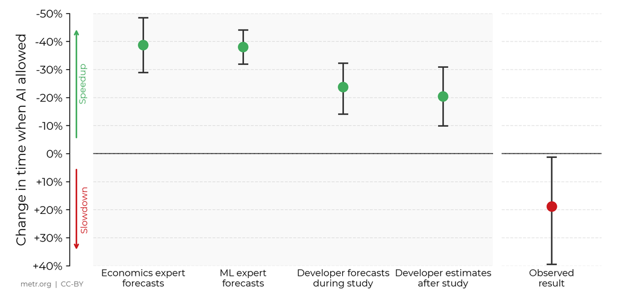

- A simple benchmark cannot find this: the **joint system** suffered
- Self-report had the sign wrong
- Analysis was… problematic

[METR (2025)](https://metr.org/blog/2025-07-10-early-2025-ai-experienced-os-dev-study/) *Measuring the Impact of Early-2025 AI on Experienced Open-Source Developer Productivity*. Figure reproduced under CC-BY.

[Recht (2025)](https://www.argmin.net/p/are-developers-finally-out-of-a-job) *Are developers finally out of a job?*

## So which model is “better”?

| Evaluation | What it actually ranks |
| --- | --- |
| A capability benchmark | which model resolves more graded items |
| A preference arena | which answer anonymous visitors like more |
| A deployment experiment | which one leaves the worker better off |

- None of the three is bad or wrong. They prioritize different things.
- “Better” is a property of model + task + user + measurement
- And it is partly a normative claim: better for whom?
  - the vendor’s launch post, the developer’s afternoon, the caseworker’s client
  - $\implies$ focus on the person who would be helped/hurt by the system

## The big idea: take measurement seriously

The move social scientists make when the thing they care about cannot be observed directly

The construct

The unobservable thing you care about

- “helpfulness”
- “safety”
- “productivity”
- “intelligence”

The operationalization

The observable procedure that stands in for it

- an MMLU score
- a resistance rate
- minutes per ticket
- an Elo rating
- Every instrument on today’s map is an operationalization of some construct
  - and the construct is usually never stated
- Social science has a name for everything that can go wrong in that gap, and a century of tools for it
  - That is why this is a social science course, taught about AI systems

Wallach, H. et al. (2025). *Evaluating Generative AI Systems is a Social Science Measurement Challenge*. (This week’s required reading.)

## Diagnosing the whole evaluation

One question at each link in the chain

| Link | The question to ask |
| --- | --- |
| Purpose | What decision, and whose, makes this worth knowing? |
| Inquiry & construct | What does “knowledge” or “resistance” mean here, exactly? |
| Sample | Which users, tasks, and prompts stand in for which others? |
| Evaluation design | Which model, prompt, scaffold, and interface were tested? |
| Observed evidence | Does the scorer measure the construct reliably and validly? |
| Answer | How uncertain is it, and how far can the claim travel? |

- Clear answers to these questions will mean you have a strong evaluation

## Today’s tour, diagnosed

| Evaluation | Where it is most exposed |
| --- | --- |
| MMLU | construct, and contamination of the evidence |
| SWE-bench | implementation: the scaffold is in the score |
| Chatbot Arena | construct: whose preference, for what |
| LLM-as-judge | measurement: is the scorer valid? |
| METR | competing measures, and how far the answer travels |

- Every one of these is a fixable statement, not a death-sentence

## This is the first half of the course

Each error family gets a week, and you build your project through them

| Week | Link in the chain | What your team produces |
| --- | --- | --- |
| 3 | Purpose, user, inquiry, construct | a design archetype, argued for |
| 4 | System boundary: what the intervention *is* | a specified AI system |
| 5 | Outcomes, raters, judges | a measurement you can defend |
| 6 | Sampling, randomization, threats to validity | a design that makes the comparison |
| 7 | Estimation, uncertainty, multiplicity | an analysis plan |
| 8 | The whole chain, registered in public | your pre-analysis plan |

- This week’s Wallach et al. reading is a preview

## The soul of the course

- Match the unit of evaluation to the purpose
  - For a deployment claim, evaluate the joint human-AI system
  - Capability and safety benchmarks answer other, well-specified questions
- Name the construct, and the person it matters to, before choosing an instrument
  - Values first, tools second
- Prefer designs whose result someone could act on
  - A decision, not a leaderboard position
- You will justify your project on these three grounds at every stage, starting next week

## Your project

Two archetypes of evaluation design

Human-subjects experiment

- Observes: a person using a tool
- Buys: the unit evaluated matches the deployment question
- Errors: recruitment, assignment, compliance, behavioral measurement

Model-only evaluation

- Observes: model on sampled tasks
- Buys: scale, reruns, and an auditable criterion
- Errors: task coverage, contamination, scorer validity, unargued purpose
- The choice changes the design and its failure modes.
  - Either can be effective

## Either way, the whole chain

- You owe an answer at every link:
  - a named purpose, and a stated construct
  - a sample whose coverage you argue for
  - a design that specifies the system being evaluated
  - evidence from a measurement you can defend
  - an answer whose claim travels no further than it should

# Your pitch for next week

## The assignment: a lightning talk

- Next session, every student pitches an evaluation question
  - At most 3 slides, 5 minutes
- After the pitches, the class votes on a small number of broad topic areas
  - Teams of ~4 form around them
- Your pitch doesn’t have to become your team’s project
  - It has to start a conversation to pursue as the project

## The shape of a good pitch

> A person, doing a task where an AI system might help, plus a reason to doubt that it does.
- Name four things, then stop
  - the person, the task, a reason it might help (pro), a reason to doubt it (con)
- The con does the work
  - “Does AI help with X?” is not a pitch
  - A pitch says why the answer isn’t obvious
- How you would measure it, and what you would randomize, come later in the course
  - Neither belongs in a five-minute pitch

## Examples: human-subjects

Public administration

- Person: a caseworker at a benefits agency
- Task: writing the letter that explains why an application was refused
- Pro: these letters are formulaic, and models draft fluent prose fast
- Con: a fluent letter subtly incorrect legally is hard to find

Hiring

- Person: a recruiter with a stack of applications
- Task: shortlisting candidates for an interview
- Pro: a CV summary cuts reading time, so more candidates get a look
- Con: what the summary leaves out may not be random
- Each con is specific to that task. Neither is a complaint about AI in general

## Examples: model-only

Content moderation

- Person: a moderator working through a queue of reported posts
- Task: deciding which ones break the platform’s hate-speech rule
- Pro: the policy is written down and most cases in the queue are easy
- Con: the hard cases may have no right answer or depend on local norms

Everyday automation

- Person: someone who has never written code
- Task: getting a script that files their email or tidies a spreadsheet
- Pro: code is what models are best at, and you can just run the script and see
- Con: unmaintanable *nearly* correct code might be worse than no code at all

## Model-only still names a person

- Nobody is in the room, so the model stands in for someone’s work
  - Name whose, and name the decision they are trying to make
- You also have to mark the model’s work
  - Either the right answers are already published
  - Or you build the cases yourself, so you know them
  - Or you use human annotation

## Pitches that don’t work (yet)

> Is GPT-5 good at law?
- No person, no task, no doubt. Which lawyer, doing which piece of work?

> Does AI make people more productive?
- Too broad for one study, and no reason to doubt. Pick one task

> We’ll compare five models on a benchmark.
- That is a leaderboard. What is the question about a person and a task underneath it?

> AI is biased and we’ll show it.
- A conclusion, not a doubt. Who is the person and what is the task?

## Sharpening your question

Five checks before you write the three slides

- Name the person. Be specific!
- Name the task this person wants to complete
- Make the pro specific: what about this task suits a model?
- Make the con specific to this task, not to AI in general
- Check the scope: could four people implement this in one term?
- If one of the five has no answer yet, say which one in the pitch
  - That gap is what the class discussion is for

## Before next week (8 September)

- Prepare your lightning talk: ≤3 slides, 5 minutes, one evaluation question
- Required readings — one from each paradigm:
  - [Dell’Acqua et al. (2023)](https://papers.ssrn.com/sol3/papers.cfm?abstract_id=4573321) — the Jagged Frontier (human-subjects)
  - [Hendrycks et al. (2021)](https://arxiv.org/abs/2009.03300) — MMLU (model-only benchmark)
  - [Chiang et al. (2024)](https://arxiv.org/abs/2403.04132) — Chatbot Arena (human preference)
- Read `example-pitches.md` in the `project-guide` repo — the shape, worked through
  - `project-scope.md` says what a project can and cannot be
- Browse the catalog of examples in the syllabus
  - pick a few near your interests
  - Get inspired by them! Get angry about what they’re leaving out!
- Reading memos (A1) start once teams form
  - Week 2 readings are for everyone to work out pitches